# Selective Disclosure

## Appendix Table D.3 — Alternative coverage restrictions

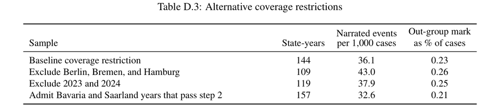

← Appendix index

## Appendix Table E.1 — Offense categories and their PKS benchmarks

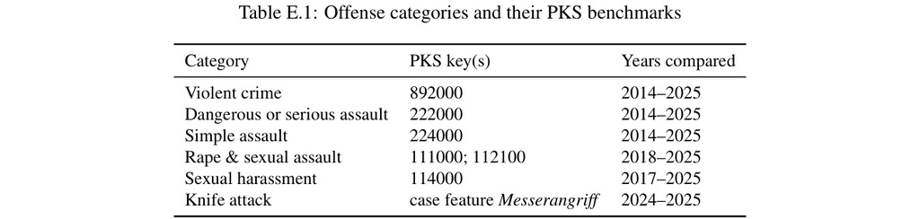

← Appendix index

## Appendix Figure F.1 — Events in the analysis dataset by publication year and state

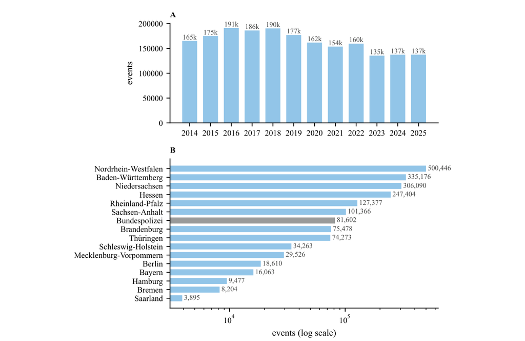

← Appendix index

## Appendix Table F.1 — From the input corpus to the analysis dataset

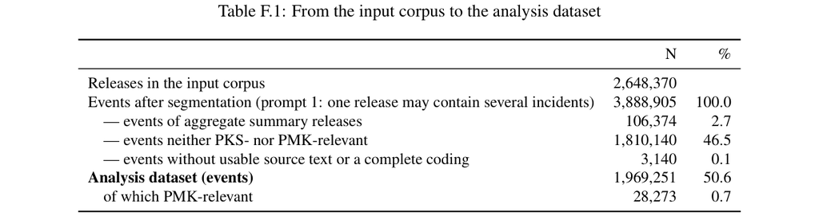

← Appendix index

## Appendix Table F.2 — Descriptive statistics for the coded variables

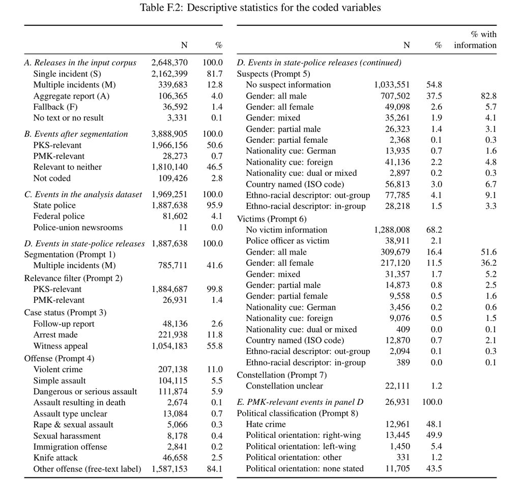

← Appendix index

## Appendix Table G.1 — Frozen inference configuration

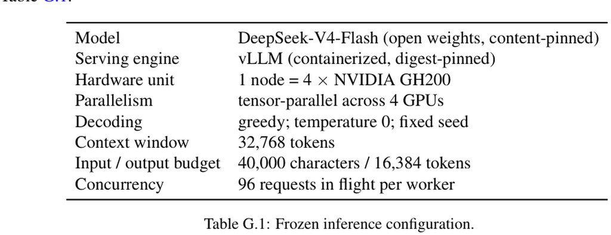

← Appendix index

## Appendix Table G.3 — Performance metrics, main model

[figure not shown]

← Appendix index

## Appendix Table G.4 — Agreement between the pipeline and refcrime

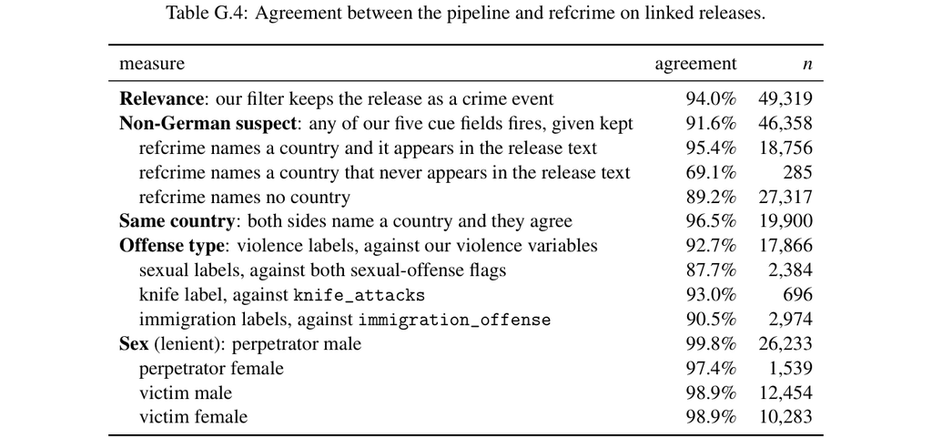

← Appendix index

## Appendix Figure G.1 — Share of events answered at each stage, by routing category

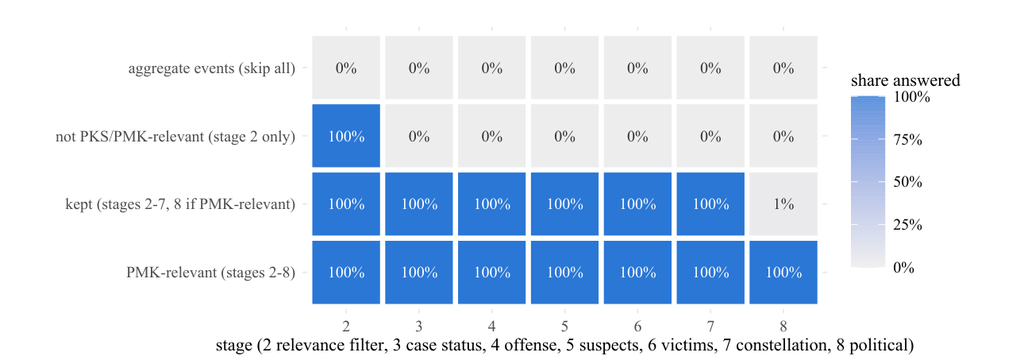

← Appendix index

## Appendix Figure G.2 — Share of events answered at each stage, by routing category and worker

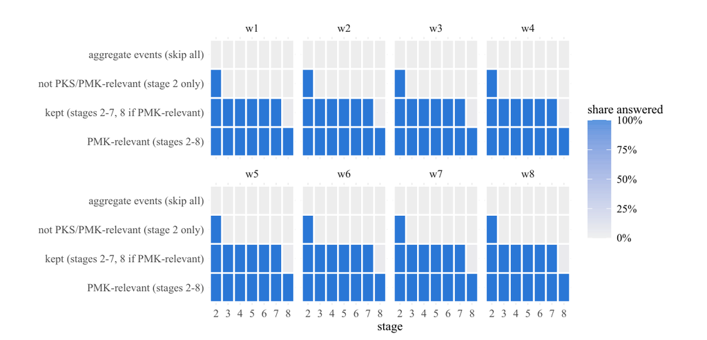

← Appendix index

## Appendix Figure G.3 — PMK-relevant events and answers at the political stage, by worker

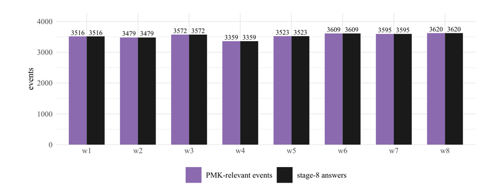

← Appendix index

## Appendix Figure G.4 — Return times of answers by prompt and worker

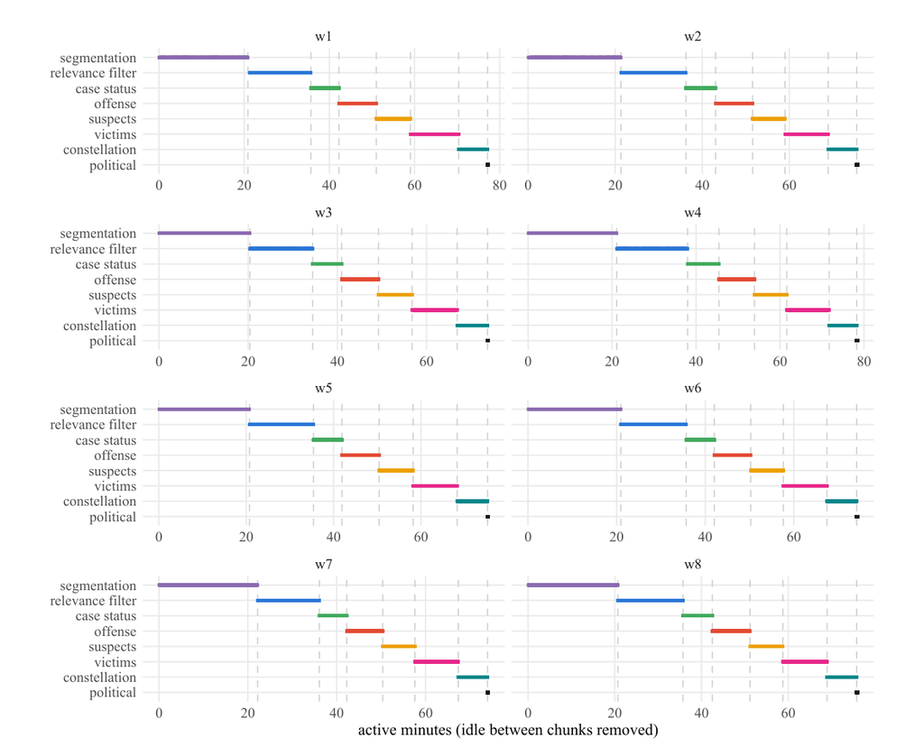

← Appendix index

## Appendix Figure G.5 — Timeline of the corpus run by worker

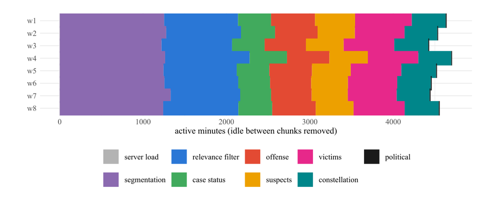

← Appendix index

## Appendix Figure G.6 — Answer length by stage and worker

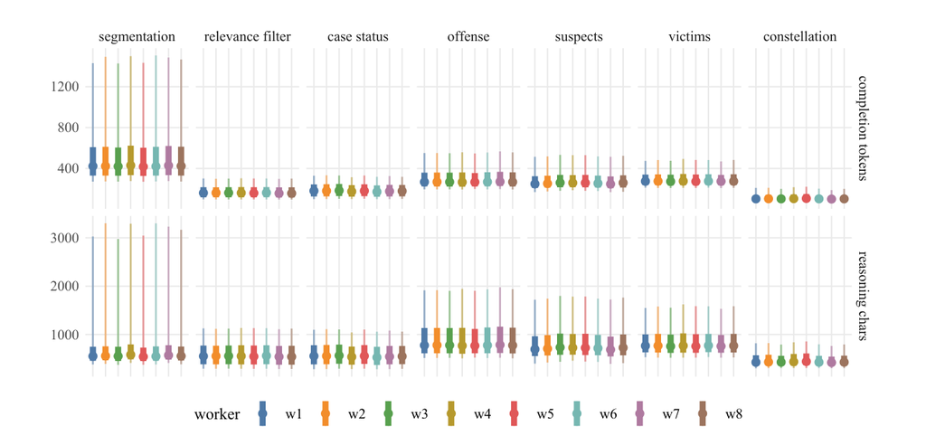

← Appendix index

## Appendix Figure G.7 — Segmentation and relevance-filter decisions by worker

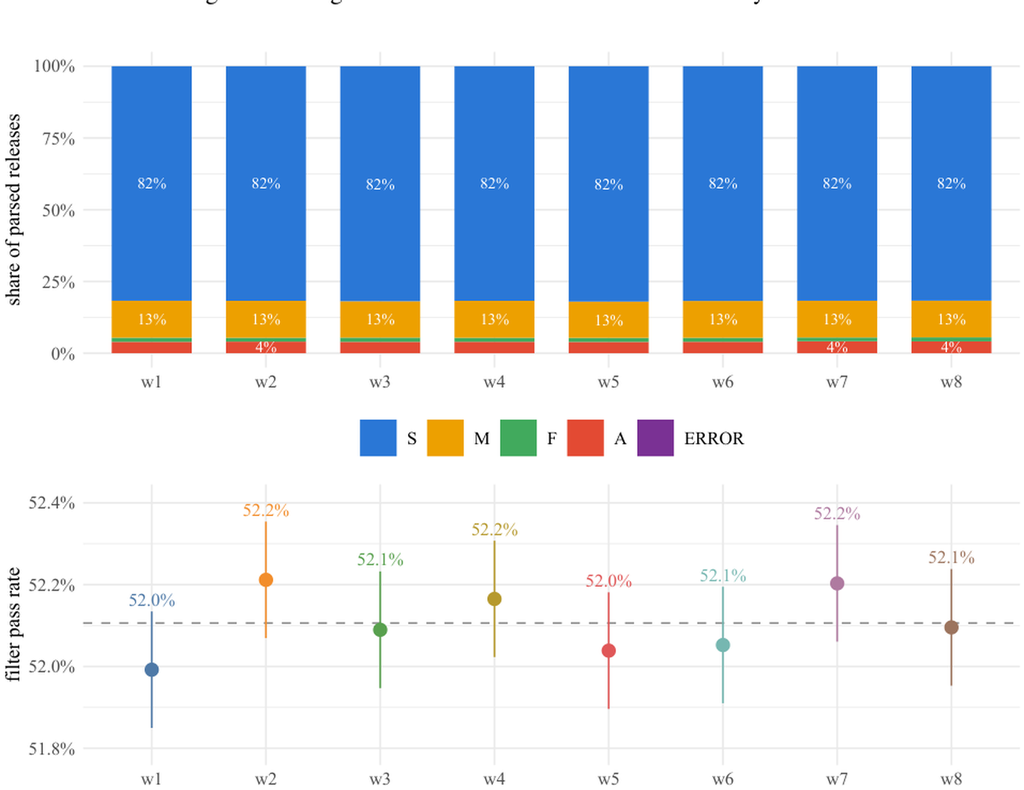

← Appendix index

## Appendix Figure G.8 — Working time per worker

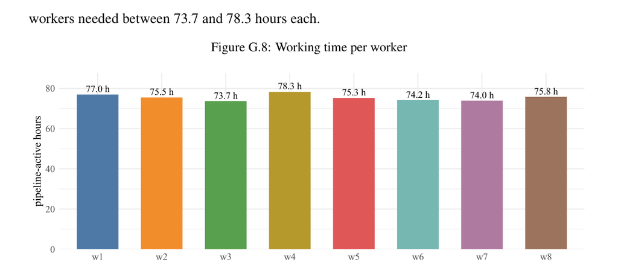

← Appendix index

## Appendix Figure G.9 — Share of answers that could be read, by stage and submission-order quartile

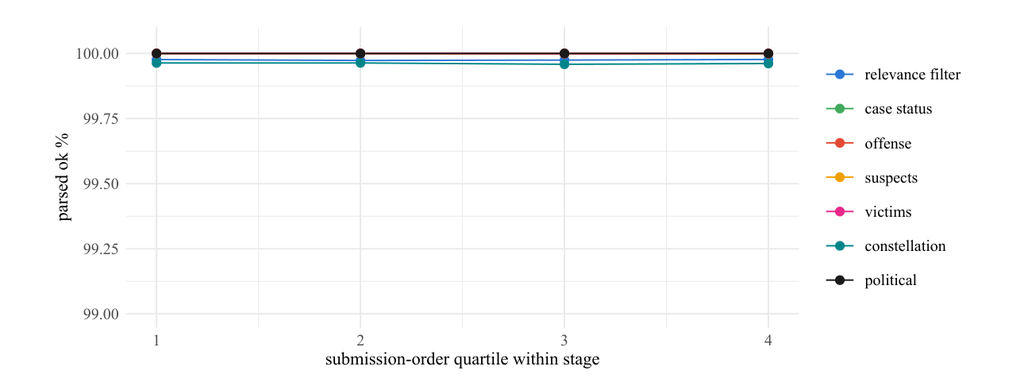

← Appendix index

## Appendix Figure G.10 — Agreement between two runs of the same 5,000 releases on the cluster

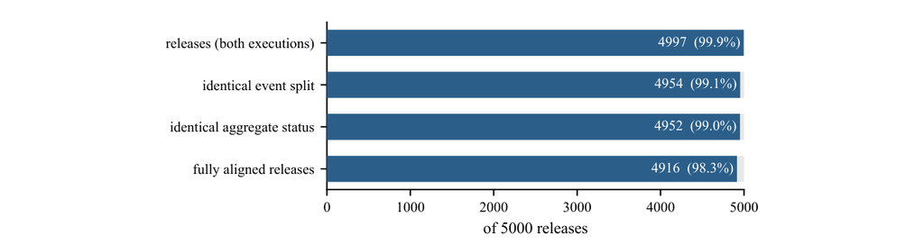

← Appendix index

## Appendix Figure H.1 — Representation ratios in police communication, by gender of suspects and victims

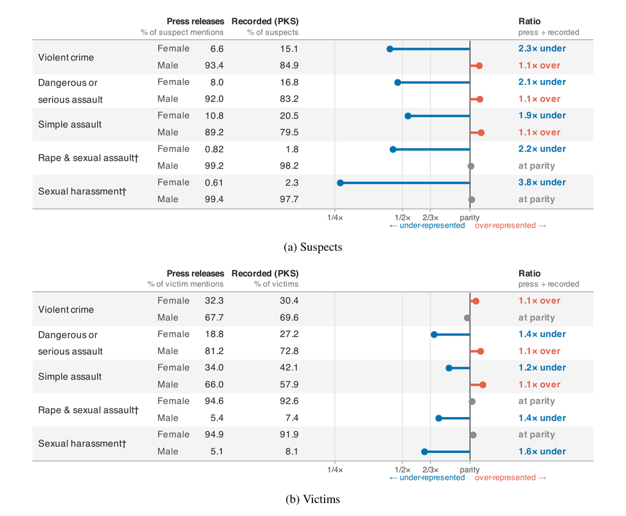

← Appendix index

## Appendix Figure H.4 — Nationalities and ethno-racial descriptors in events with suspect information, by case status

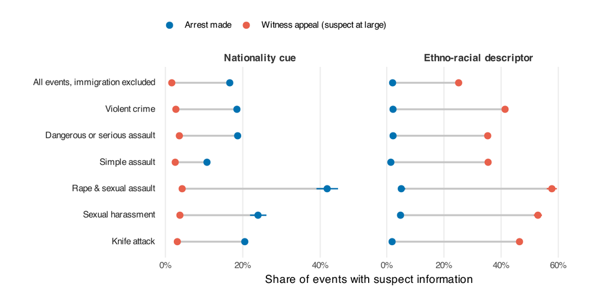

← Appendix index

## Appendix Figure H.5 — Origin cues over time

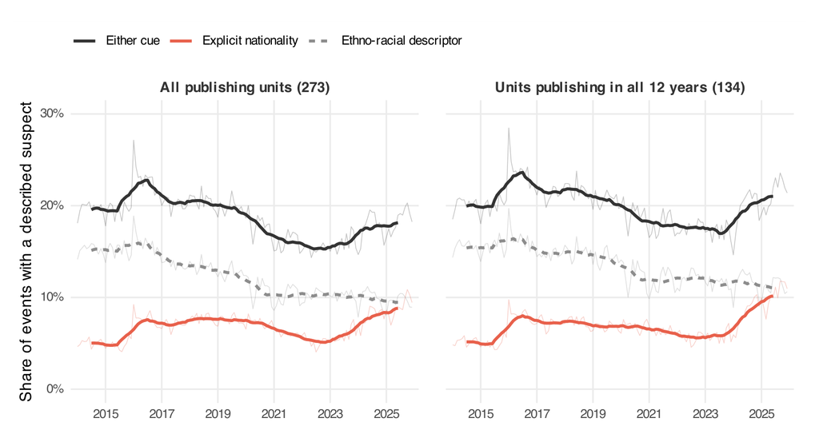

← Appendix index

## Appendix Figure H.6 — Out-group cues in police press communication over time

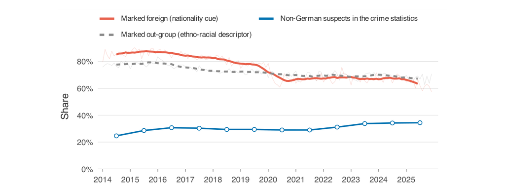

← Appendix index

## Appendix Figure I.1 — Unattributed republication

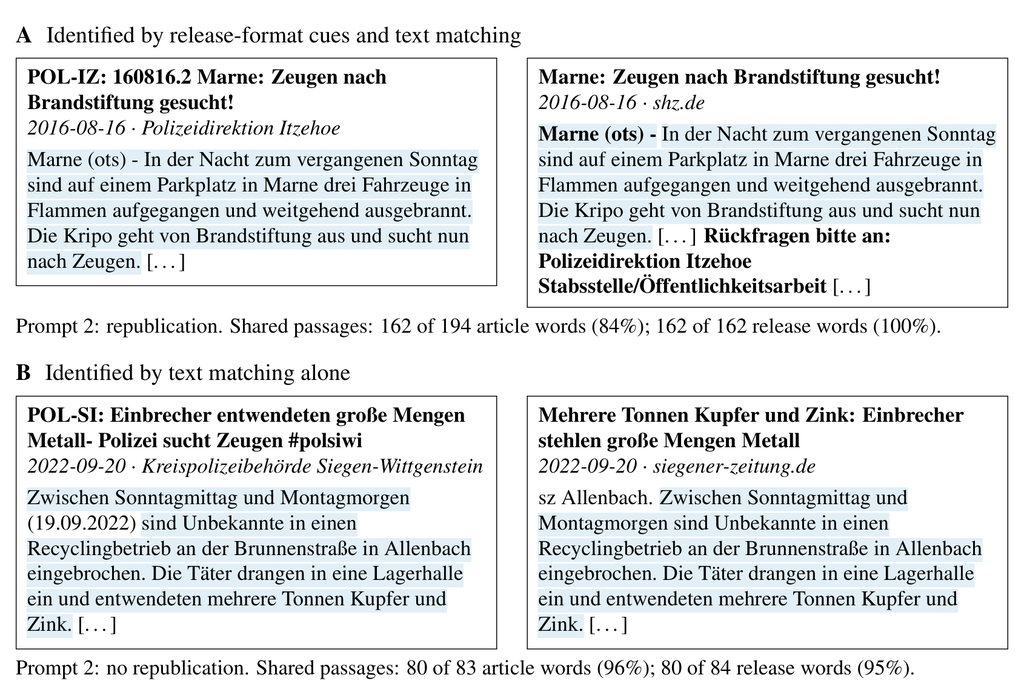

← Appendix index

## Appendix Table I.1 — Outlets and article coverage

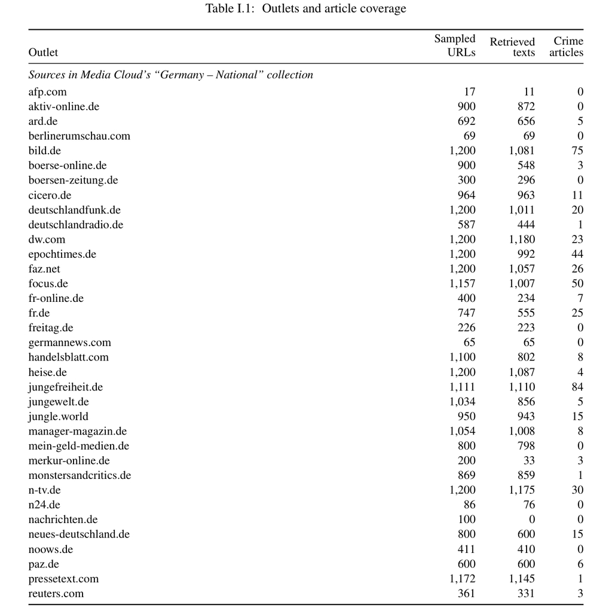

← Appendix index

## Appendix Figure J.2 — Placebo distribution of right-bloc estimates

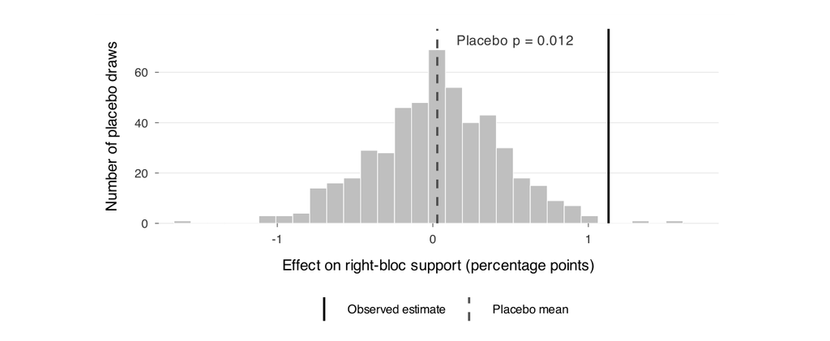

← Appendix index

## Appendix Table J.1 — Main results, estimated jointly for both marker groups

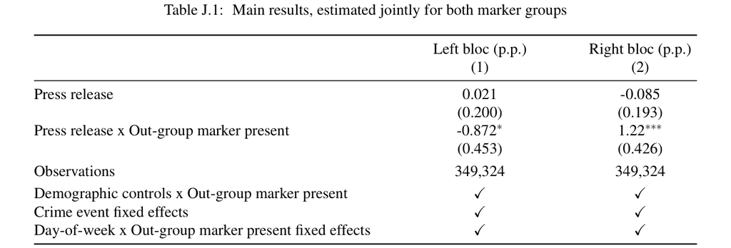

← Appendix index

## Appendix Table J.2 — One randomly selected publication window per respondent

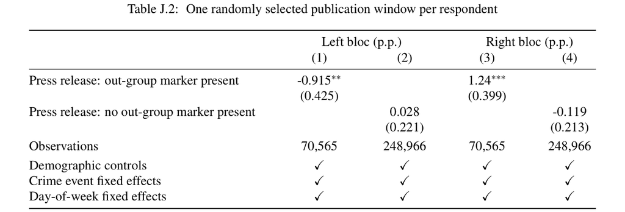

← Appendix index

## Appendix Table J.3 — Main results, without demographic controls

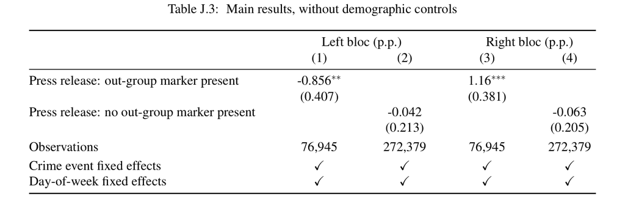

← Appendix index

## Appendix Table J.4 — Alternative fixed effects

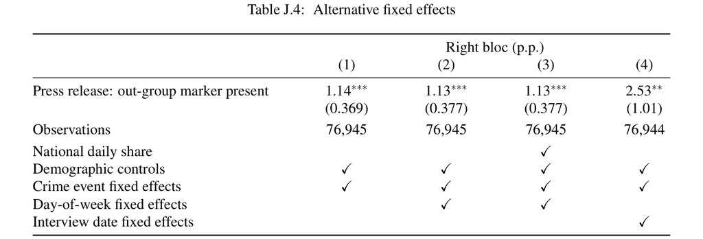

← Appendix index

## Appendix Figure J.3 — Covariate balance

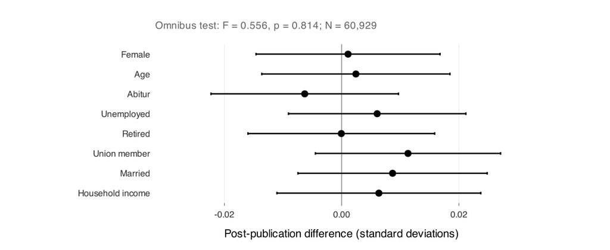

← Appendix index

## Appendix Figure J.4 — Right-bloc estimates by interview window

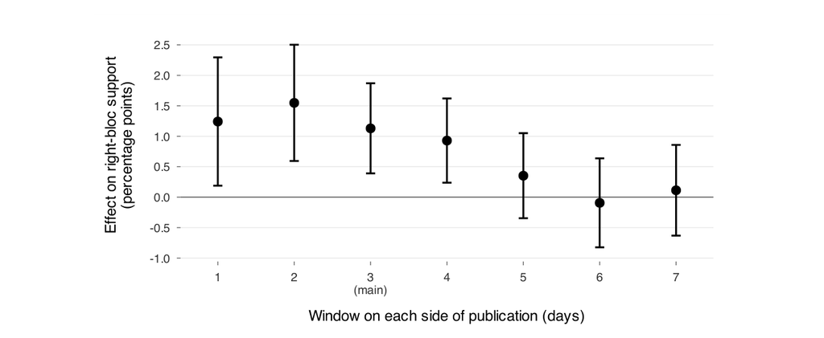

← Appendix index

## Appendix Table J.5 — Effects on individual parties

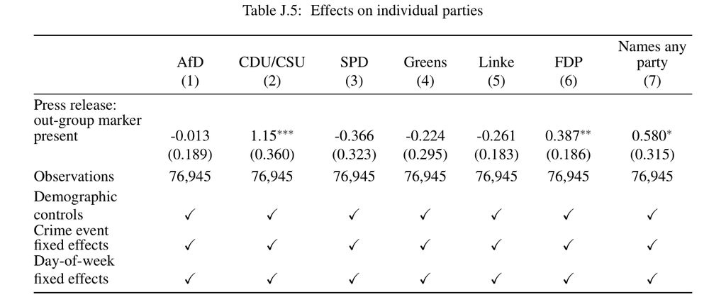

← Appendix index

## Appendix Table J.6 — Heterogeneity by respondent characteristics

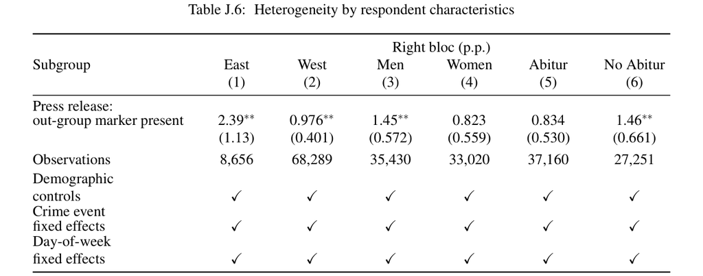

← Appendix index

## Appendix Figure K.2 — MV event-study vs placebo states

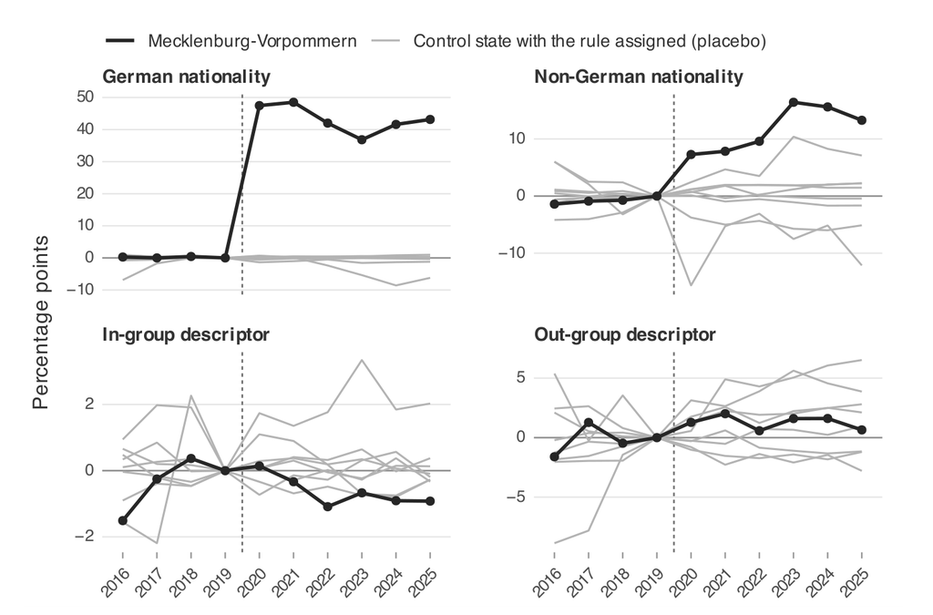

← Appendix index

## Potential mechanism: immigration salience

When immigration is politically salient, press offices increase out-group disclosure to signal transparency.

Police interview

> “So I was very involved in the so-called refugee issue, I believe it was around 2019, when there were also many incidents. During that period, we communicated such incidents involving asylum seekers with **maximum transparency** because we did not want accusations or criticism from the right-wing spectrum claiming we were hiding something…”

Related working paper

[figure not shown]

Elshehawy, Frey, Haas, Riaz & Roemer — osf.io/trhys_v1

← Appendix index

## Interview Quote 1

> “So I was very involved in the so-called refugee issue, I believe it was around 2019, when there were also many incidents. During that period, we communicated such incidents involving asylum seekers with maximum transparency because we did not want accusations or criticism from the right-wing spectrum claiming we were hiding something or allowing a narrative to emerge that we remain silent when a particular group of people, who are central to the discussion here, commit something like shoplifting.”

← Back · Appendix index

## Interview Quote 2

> “…when we currently deal with people of Russian or Ukrainian descent, we aim to be transparent about this as well, because it is now a topic that concerns the public and people in general. We are thus more sensitive in these cases, whereas perhaps five years ago we wouldn’t have even considered whether we should specifically address conflicts here between Russians and Ukrainians.”

← Back · Appendix index